# Supplementary Figure 1b

miR34a asRNA and miR34a TCGA expression

Jimmy Van den Eynden and Jason T. Serviss

31/01/2017

#### *Introduction*

We interogated RNA sequencing data from TCGA to determine in miR34a and miR34a asRNA expression was correlated in both TP53 wild type and mutated samples.

#### *Methods*

RNA-Seq data and copy number data were downloaded from TCGA and processed as described previously (Ashouri et al. 2016). Briefly, RNA-Seq data were aligned to the human hg19 assembly and quantified using GENCODE (v19) annotated HTSeq-counts and FPKM normalizations. Expression data from miR34a and miR34 asRNA (identified as RP3-510D11.2) were used for further analysis. Copy number amplitudes for GENCODE genes were determined from segmented copy-number data. Samples that were diploid for miR34 asRNA were identified as those samples that had copy number amplitudes between -0.1 and 0.1.

Somatic mutation data were downloaded from the Genomics Data Commons data portal (GDC) as mutation annotation format (maf) files, called using Mutect2 on 30/10/2017 (v7) (Grossman et al. 2016).

#### *Results*

```r
data <- getData("Supplementary Figure 1b")

#normalize expression values
data <- mutate(
    data,
    RP3 = log2(RP3 / max(RP3)),
    miR34a = log2(miR34a / max(miR34a))
  )

#add BRCA subtypes
data <- data %>%
  mutate(PAM50 = if_else(is.na(PAM50), "", PAM50)) %>%
  mutate(cancer_PAM50 = gsub("BRCA", "BRCA ", paste(cancer, PAM50, sep = "")))

#sort
data <- arrange(data, cancer_PAM50, TP53, RP3)

#remove infinite data
data <- filter(data, !is.infinite(RP3) & !is.infinite(miR34a))

#diploid only
data <- filter(data, abs(RP3_cna) < 0.1)

##prepare for plotting
data <- data %>%
  mutate(TP53 = if_else(TP53 == 0, "TP53 wt", "TP53 mut")) %>%
  select(TCGA_cancer_id, TP53, cancer_PAM50, RP3, miR34a) %>%
  gather(gene, value, -(TCGA_cancer_id:cancer_PAM50)) %>%
  mutate(gene = if_else(gene == "RP3", "lncTAM34a", "miR34a"))

#remove cancers that don't have at least 5 patients in both TP53 wt and mutated
data <- data %>%
  group_by(cancer_PAM50, TP53, gene) %>%
  filter(n() > 5) %>%
  group_by(cancer_PAM50, gene) %>%
  filter(length(unique(TP53)) == 2) %>%
  ungroup()

#calculate stats
stats <- data %>%
  group_by(cancer_PAM50, gene, TP53) %>%
  summarize(value = list(value)) %>%
  spread(TP53, value) %>%
  mutate(
    median_wt = median(unlist(`TP53 wt`)),
    median_mut = median(unlist(`TP53 mut`)),
    CI95l_wt = t.test(unlist(`TP53 wt`))$conf.int[1],
    CI95l_mut = t.test(unlist(`TP53 mut`))$conf.int[1],
    CI95h_wt = t.test(unlist(`TP53 wt`))$conf.int[2],
    CI95h_mut = t.test(unlist(`TP53 mut`))$conf.int[2],
    pValue = wilcox.test(unlist(`TP53 wt`), unlist(`TP53 mut`), alternative = "two.sided")$p.value
  ) %>%
  ungroup() %>%
  gather(metric, value, -(cancer_PAM50:`TP53 wt`), -pValue) %>%
  separate(col = metric, into = c("metric", "TP53"), sep = "_") %>%
  spread(metric, value) %>%
  mutate(TP53 = if_else(TP53 == "wt", "TP53 wt", "TP53 mut")) %>%
  pFormat(.)

#add fake data where p53 mut is missing (will be hidden in plot) to keep empty space
data <- data %>%
  mutate(TP53 = parse_factor(TP53, levels = c("TP53 wt", "TP53 mut"))) %>%
  mutate(gene = parse_factor(gene, levels = c("lncTAM34a", "miR34a"))) %>%
  mutate(cancer_PAM50 = parse_factor(cancer_PAM50, levels = rev(unique(cancer_PAM50))))

stats <- stats %>%
  mutate(TP53 = parse_factor(TP53, levels = c("TP53 wt", "TP53 mut"))) %>%
  mutate(gene = parse_factor(gene, levels = c("lncTAM34a", "miR34a"))) %>%
  mutate(cancer_PAM50 = parse_factor(cancer_PAM50, levels = rev(unique(cancer_PAM50))))
```

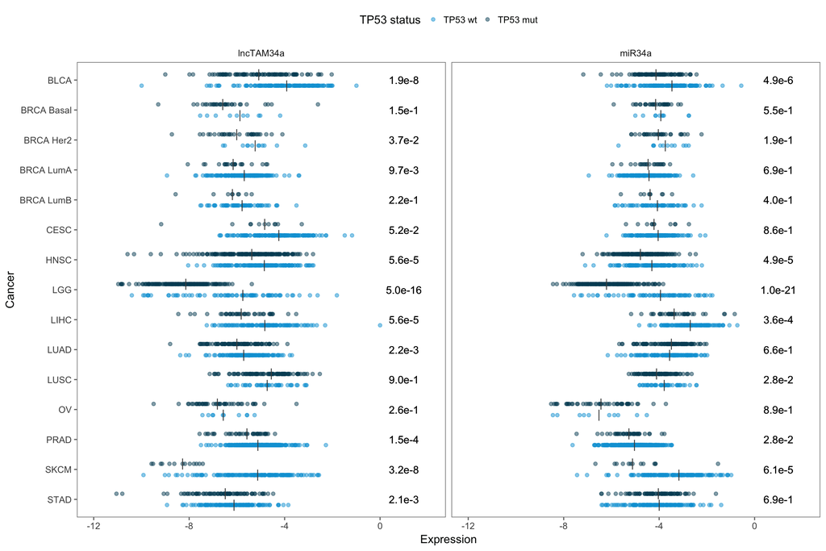

```r
ggplot(data = NULL) +
  geom_jitter(
    data = data,
    aes(
      x = cancer_PAM50,
      y = value,
      colour = TP53
    ),
    position = position_dodge(width = 0.75),
    alpha = 0.5
  ) +
  geom_text(
    data = stats,
    aes(
      x = cancer_PAM50,
      y = 1,
      label = pFormat
    )
  ) +
  geom_point(
    data = stats,
    aes(
      x = cancer_PAM50,
      y = median,
      group = TP53
    ),
    colour = "grey30",
    shape = 124,
    size = 4,
    lwd = 1,
    position = position_dodge(width = 0.75)
  ) +
  facet_wrap(~gene, ncol = 2) +
  coord_flip(ylim = c(-12, 2.05)) +
  labs(
    x = "Cancer",
    y = "Expression"
  ) +
  theme_few() +
  scale_colour_economist() +
  theme(legend.position = "top") +
  guides(colour = guide_legend(title = "TP53 status"))
```

```r
#plot pdf
figure <- ggplot(data = NULL) +
  geom_jitter(
    data = data,
    aes(
      x = cancer_PAM50,
      y = value,
      colour = TP53
    ),
    position = position_dodge(width = 0.75),
    alpha = 0.5,
    size = 1
  ) +
  geom_text(
    data = stats,
    aes(
      x = cancer_PAM50,
      y = 1,
      label = pFormat
    ),
    size = 3.25
  ) +
  geom_point(
    data = stats,
    aes(
      x = cancer_PAM50,
      y = median,
      group = TP53
    ),
    colour = "grey30",
    shape = 124,
    size = 4,
    lwd = 1,
    position = position_dodge(width = 0.75)
  ) +
  facet_wrap(~gene, ncol = 2) +
  coord_flip(ylim = c(-12, 2.05)) +
  labs(
    x = "Cancer",
    y = "Expression"
  ) +
  theme_few() +
  scale_colour_economist() +
  theme(
    plot.margin = unit(rep(0.1, 4), "lines"),
    legend.position = "top",
    legend.background = element_blank(),
    legend.box.spacing = unit(5, "pt"), #this controls the spacing between strip.text.x and the legend
    legend.margin = margin(rep(0, 4), unit = "pt"),
    legend.key.size = unit(1/5, "cm"),
    legend.title = element_text(size = 9),
    legend.text = element_text(size = 7),
    axis.title.y = element_blank(),
    axis.title.x = element_text(size = 9, margin = margin(t = 5)),
    axis.text.y = element_text(size = 10),
    axis.text.x = element_text(size = 10),
    axis.ticks = element_line(size = 0.25),
    axis.ticks.length = unit(1/15, "cm"),
    panel.border = element_rect(fill = NA, size = 0.15)
  ) +
  guides(colour = guide_legend(title = "TP53 status", override.aes = list(size = 3, alpha = 1)))

##save to pdf
# path <- file.path("~/GitHub/miR34a_asRNA_project/inst", fileMap(type = "pdf")["Figure 1-Supplement 1b"][[1]])
# ggsave(
#    plot = figure,
#    filename = path,
#    device = cairo_pdf,
#    height = 135,
#    width = 205,
#    units = "mm"
# )
```

A graphical depiction of the TCGA expression analysis. P-values are shown on the right side of each panel and compare TP53 wild type samples with nonsynonymous TP53 muated samples. The small vertical line indicated the median. Bladder Urothelial Carcinoma (BLCA), Breast invasive carcinoma (BRCA), Head and Neck squamous cell carcinoma (HNSC), Lower Grade Glioma (LGG), Liver hepatocellular carcinoma (LIHC), Lung adenocarcinoma (LUAD), Lung squamous cell carcinoma (LUSC), Ovarian serous cystadenocarcinoma (OV), Prostate adenocarcinoma (PRAD), Skin Cutaneous Melanoma (SKCM), Stomach adenocarcinoma (STAD).

#### *Conclusions*

miR34a asRNA and miR34a tend to exhibit a decreased expression in cancer types examined in patients with TP53 mutations.